# Importance Sampling

Hwang Seong-Yun

2021 2 16

## f(x)를 density estimator로 추정 후 g(y)를 적절히 선택하여 분산을 줄일 수 있는지 확인 (R의 density 함수, kde package ?)

- $E _{g} [f(X)]= \int _{} ^{} {f(x)g(x)dx= \int _{} ^{} {\frac {f(x)g(x)} {h(x)} h(x)dx=E _{h} [\frac {f(X)g(X)} {h(X)} ]=m}}$
- $V _{1} ,V _{2} ,...,V _{n} -> h(v)$
- ${\hat{m}} = \frac {1}{n} \sum _{i=1} ^{n} \frac{f(V _{i} )g(V _{i} )} {h(V _{i} )}$
- 주어진 자료에 대한 분포가 주어지지 않은 경우에는 그 분포를 추정해야 함. (g(x)를 추정)
- 이후 추정된 분포 g(x)에 대한 특정값에서의 함수값을 구하는 것이 관건이라고 판단됨. 이 문제가 해결된다면 importance sampling에 대한 성능평가를 제대로 할 수 있음.

### Case1) g(x) : Gamma(2,3) , h(x) : Gamma(3,4)

- $X \sim Gamma(\alpha,\beta )$
- $f _{X} (x)= \frac{1} {\Gamma(\alpha)\beta^{\alpha }} x ^{\alpha -1} e ^{-\frac {x} {\beta }} ,x>0,\Gamma (\alpha )= \int _{0} ^{\infty} {x ^{\alpha -1}} e ^{-x} dx$
- $E(X)= \alpha \beta , Var(X)= \alpha \beta ^{2}$
- 이론적으로 Gamma(2,3) 에 대한 평균은 6이다.
- 이에 대해 g(x) : Gamma(2,3) 에서 난수를 추출한 경우와 h(x) : Gamma(3,4) 를 이용한 importance sampling을 적용했을 때 분산이 어떻게 차이가 나는지 모의실험을 통해 확인하는 것이 목적임.

#### Graph of g(x) and h(x)

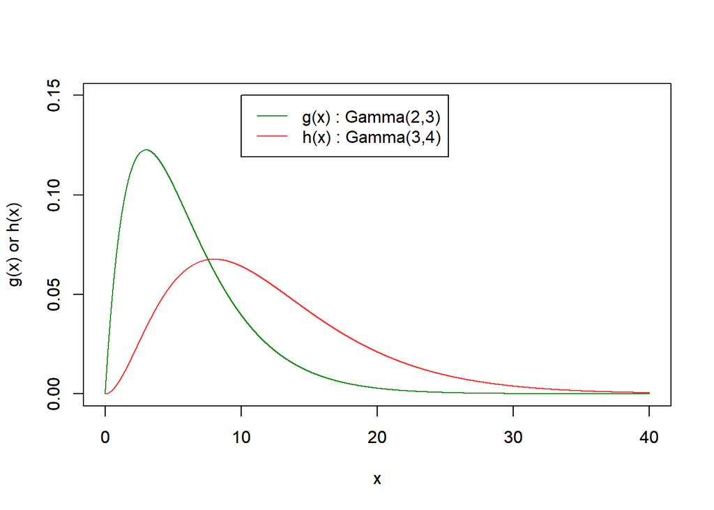

```r
x <- seq(0,40,0.001)
g <- dgamma(x,shape=2,scale=3)
h <- dgamma(x,shape=3,scale=4)
plot(x,g,ylab="g(x) or h(x)",xlab="x",ylim=c(0,0.15),type="l",col="#228B22")
par(new=T)
plot(x,h,ylab="",xlab="x",ylim=c(0,0.15),type="l",col="#FF3030")
legend(x=10,y=0.15, c("g(x) : Gamma(2,3)","h(x) : Gamma(3,4)"),lty=1,col=c("#228B22","#FF3030"))
```

- h(x)를 g(x)에 비해 오른쪽 꼬리가 더 두꺼운 분포로 선정함.

#### 모의실험

- 다음의 두가지 방법을 비교하기 위한 모의실험
- 1. 실제 분포인 g(x)를 통해 난수 추출
- 2. h(x)를 이용한 importance sampling을 통해 난수 추출
- 1,2의 방법을 통해 1000개의 난수를 추출하고 각각의 평균과 분산을 계산함.
- 이 과정을 1000번 반복하여 결과를 확인.

```r
GM <- c()
GV <- c()
GB <- c()
ISM <- c()
ISV <- c()
ISB <- c()
for (i in 1:1000) {
  gr <- rgamma(1000,shape=2,scale=3)
  GM[i] <- mean(gr)
  GV[i] <- var(gr)
  GB[i] <- abs(mean(gr)-6)
  v <- rgamma(1000,shape=3,scale=4)
  g <- dgamma(v,shape=2,scale=3)
  h <- dgamma(v,shape=3,scale=4)
  ISM[i] <- mean(v*g/h)
  ISV[i] <- var(v*g/h)
  ISB[i] <- abs(mean(v*g/h)-6)
}
res1 <- data.frame(mean=c(GM,ISM),variance=c(GV,ISV),bias=c(GB,ISB),method=c(rep("Sampling",1000),rep("Importance Sampling",1000)))
```

- 평균추정결과

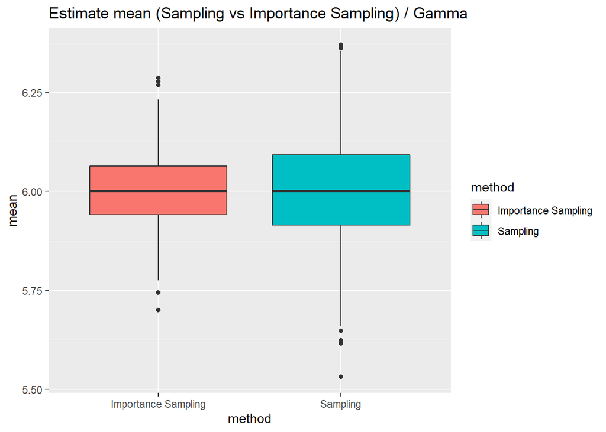

```r
library(ggplot2)
ggplot(res1,aes(x=method,y=mean,fill=method)) +
  geom_boxplot() +
  ggtitle("Estimate mean (Sampling vs Importance Sampling) / Gamma")
```

- 분산 비교

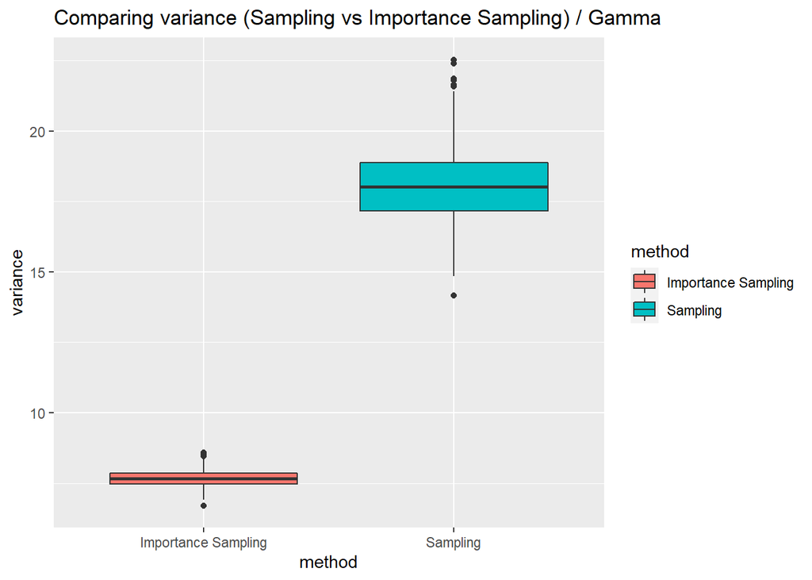

```r
ggplot(res1,aes(x=method,y=variance,fill=method)) +
  geom_boxplot() +
  ggtitle("Comparing variance (Sampling vs Importance Sampling) / Gamma")
```

- 편향 비교

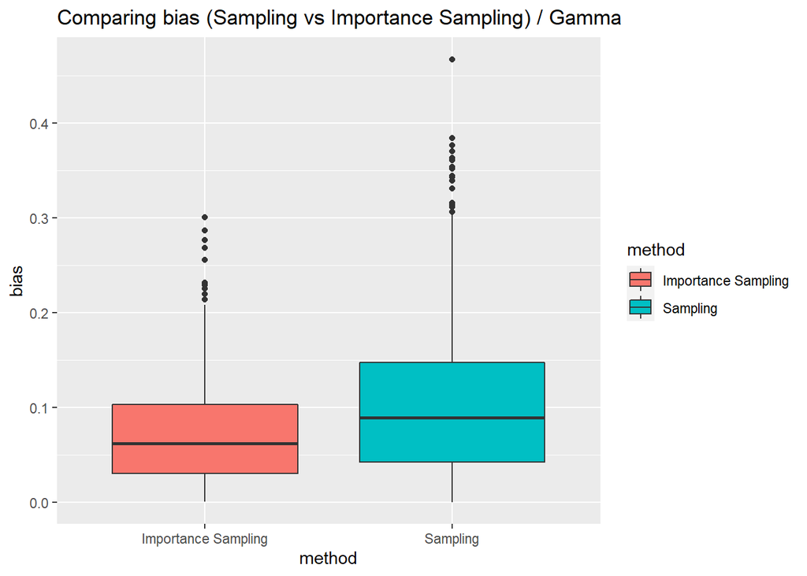

```r
ggplot(res1,aes(x=method,y=bias,fill=method)) +
  geom_boxplot() +
  ggtitle("Comparing bias (Sampling vs Importance Sampling) / Gamma")
```

- 결과적으로 Importance Sampling을 적용했을 경우 분산과 편향 모두 감소함을 확인할 수 있다.

### Case2) g(x) : Weibull(2,3) , h(x) : Weibull(2,4)

- $X \sim Weibull(\alpha,\beta )$
- $f _{X} (x)=( \frac{\alpha } {\beta } )(\frac {x} {\beta } ) ^{\alpha -1} exp(-(\frac {x} {\beta } ) ^{\alpha } ),x>0$
- $E(X)= \beta \Gamma (1+ \frac{1} {\alpha } ),Var(X)= \beta ^{2} [ \Gamma (1+ \frac{2} {\alpha } )- (\Gamma (1+ \frac{1} {\alpha } )) ^{2} ]$
- 이론적으로 Weibull(2,3) 에 대한 평균은 2.658681이다.
- 이에 대해 g(x) : Weibull(2,3) 에서 난수를 추출한 경우와 h(x) : Weibull(2,4) 를 이용한 importance sampling을 적용했을 때 분산이 어떻게 차이가 나는지 모의실험을 통해 확인하는 것이 목적임.

#### Graph of g(x) and h(x)

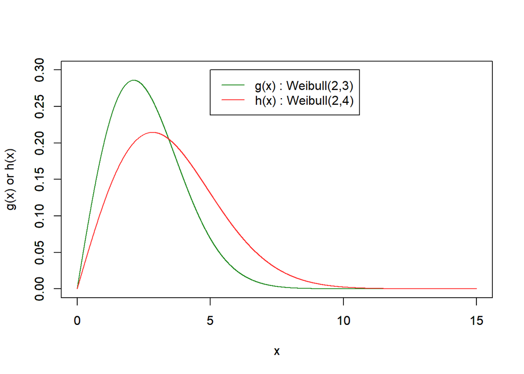

```r
x <- seq(0,15,0.001)
g <- dweibull(x,shape=2,scale=3)
h <- dweibull(x,shape=2,scale=4)
plot(x,g,ylab="g(x) or h(x)",xlab="x",ylim=c(0,0.3),type="l",col="#228B22")
par(new=T)
plot(x,h,ylab="",xlab="x",ylim=c(0,0.3),type="l",col="#FF3030")
legend(x=5,y=0.3, c("g(x) : Weibull(2,3)","h(x) : Weibull(2,4)"),lty=1,col=c("#228B22","#FF3030"))
```

- h(x)를 g(x)에 비해 오른쪽 꼬리가 더 두꺼운 분포로 선정함.

#### 모의실험

- 다음의 두가지 방법을 비교하기 위한 모의실험
- 1. 실제 분포인 g(x)를 통해 난수 추출
- 2. h(x)를 이용한 importance sampling을 통해 난수 추출
- 1,2의 방법을 통해 1000개의 난수를 추출하고 각각의 평균과 분산을 계산함.
- 이 과정을 1000번 반복하여 결과를 확인.

```r
GM <- c()
GV <- c()
GB <- c()
ISM <- c()
ISV <- c()
ISB <- c()
for (i in 1:1000) {
  gr <- rweibull(1000,shape=2,scale=3)
  GM[i] <- mean(gr)
  GV[i] <- var(gr)
  GB[i] <- abs(mean(gr)-3*gamma(1+1/2))
  v <- rweibull(1000,shape=2,scale=4)
  g <- dweibull(v,shape=2,scale=3)
  h <- dweibull(v,shape=2,scale=4)
  ISM[i] <- mean(v*g/h)
  ISV[i] <- var(v*g/h)
  ISB[i] <- abs(mean(v*g/h)-3*gamma(1+1/2))
}
res2 <- data.frame(mean=c(GM,ISM),variance=c(GV,ISV),bias=c(GB,ISB),method=c(rep("Sampling",1000),rep("Importance Sampling",1000)))
```

- 평균추정결과

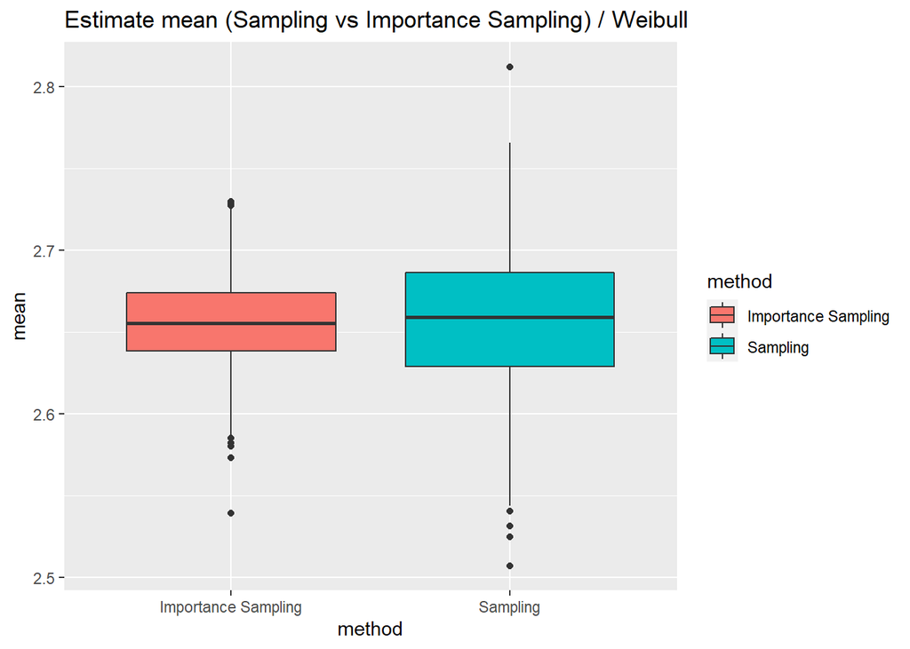

```r
library(ggplot2)
ggplot(res2,aes(x=method,y=mean,fill=method)) +
  geom_boxplot() +
  ggtitle("Estimate mean (Sampling vs Importance Sampling) / Weibull")
```

- 분산 비교

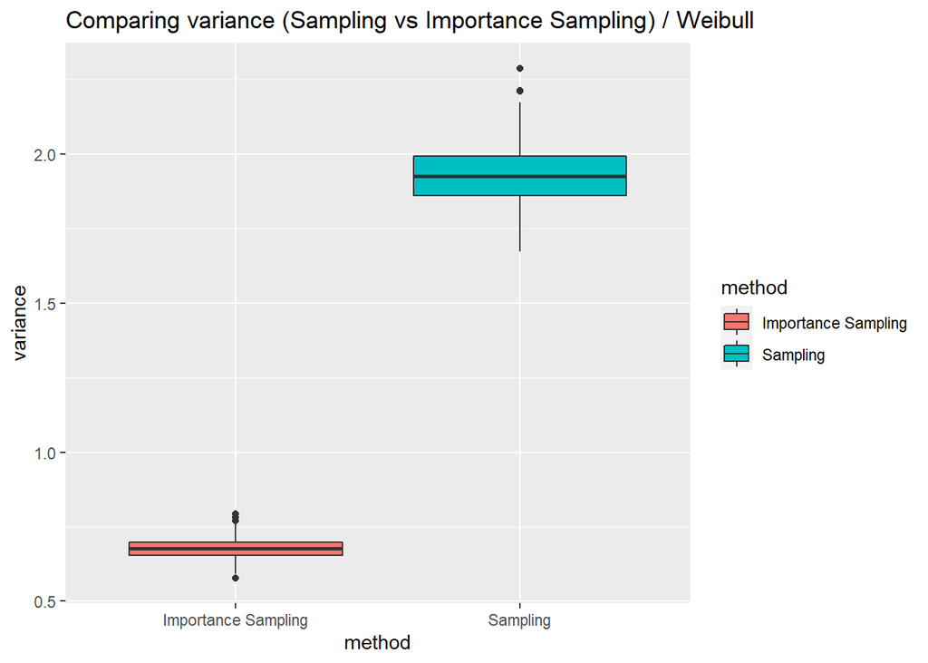

```r
ggplot(res2,aes(x=method,y=variance,fill=method)) +
  geom_boxplot() +
  ggtitle("Comparing variance (Sampling vs Importance Sampling) / Weibull")
```

- 편향 비교

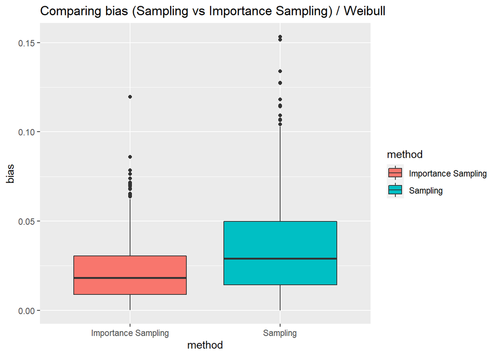

```r
ggplot(res2,aes(x=method,y=bias,fill=method)) +
  geom_boxplot() +
  ggtitle("Comparing bias (Sampling vs Importance Sampling) / Weibull")
```

- 결과적으로 Importance Sampling을 적용했을 경우 분산과 편향 모두 감소함을 확인할 수 있다.